# Lab 14: Robust Linear Regression and MCMC

Daniel Carpenter

April 2022

# MCMC problem

We have learnt a lot about GLM regression. One MCMC problem we may encounter is strong covariance between parameters. This will cause the sampler to move slowly through the parameter space and cause strong autocorrelation for a parameter.

## Fix

One method to fix this is to transform the x and y variables. This may also help for situations where the size of the x and y metrics are large for the computer numerics.

## Standardize the variables

Note that $Z$ has mean 0 and standard deviation 1.

$$Z=\frac{X-\bar{X}}{S_X}$$

# Task 1

Prove sample mean of $Z$ is 0 and standard deviation is 1.

Sample mean:
$$E[Z]=E\left[\frac{X-\bar{X}}{S_{X}}\right]=\frac{1}{S_{X}}[E[X]-\bar{X}]=\frac{1}{S_{X}}[\bar{X}-\bar{X}]=0$$

Standard deviation:
$$\begin{aligned}
\operatorname{Var}\left[Z^{2}\right] &=E\left[Z^{2}\right]-E^{2}[Z] \\
&=E\left[\left(\frac{X-\bar{X}}{S_{X}}\right)^{2}\right]-0^{2} \\
&=\frac{1}{S_{X}^{2}}\left[E\left[X^{2}\right]-2 \bar{X} E[X]+\bar{X}^{2}\right] \\
&=\frac{1}{S_{X}^{2}}\left[\left\{E\left[X^{2}\right]-E^{2}[X]\right\}+E^{2}[X]-2 \bar{X} E[X]+\bar{X}^{2}\right] \\
&=\frac{1}{S_{X}^{2}}\left[\{\operatorname{Var}[X]\}+\bar{X}^{2}-2 \bar{X}^{2}+\bar{X}^{2}\right] \\
&=\frac{1}{S_{X}^{2}}\left[S_{X}^{2}+0\right] \\
&=1
\end{aligned}$$

# Outliers problem

Outliers can be a problem because they may overly influence an analysis - meaning they might be most responsible for parameter estimates and dominate the rest of the data in terms of their impact on estimates.

One method to lessen the impact of outliers is to use a distribution on Y that has large tails.

## Fix

Partial fix: The t-distribution would be a suitable replacement to the normal.

Read pages 479-487 (Section 17.2)

# Task 2

After reading the above sections do the following:

## Make a Jags model that will analyze the following simulated data

Do this by NOT using a t distribution and NOT using ceneterd variables. Make sure you diagnose the MCMC

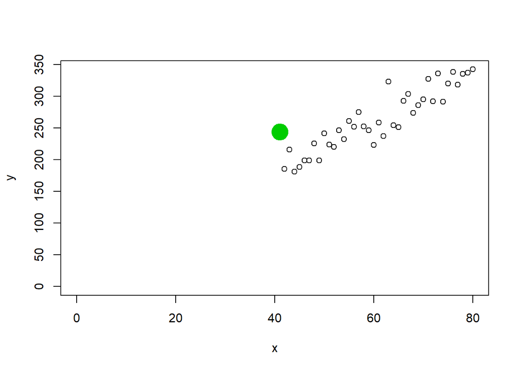

```r
x = 42:80
set.seed(34) # we will all have the same data
y = 20 + 4*x + rnorm(39,0,20)
xx = 41
yy = 20+4*xx + 60
x = c(xx,x)
y = c(yy, y)
plot(y~x, xlim=range(c(0, x)),ylim=range(c(0,y)))
points(xx,yy,pch=19,cex=3,col="green3")
```

## Make a jags model that will analyze the data.

See pages 485-486. This time center the data and use a t distribution. Make sure you diagnose the MCMC. Back transform (transform to original scale) and then:

### JAGS Model without Overcoming Outlier

```r
source("DBDA2E-utilities.R") # Must be in R's current working directory.
```

```
##
## Kruschke, J. K. (2015). Doing Bayesian Data Analysis, Second Edition:
## A Tutorial with R, JAGS, and Stan. Academic Press / Elsevier.
```

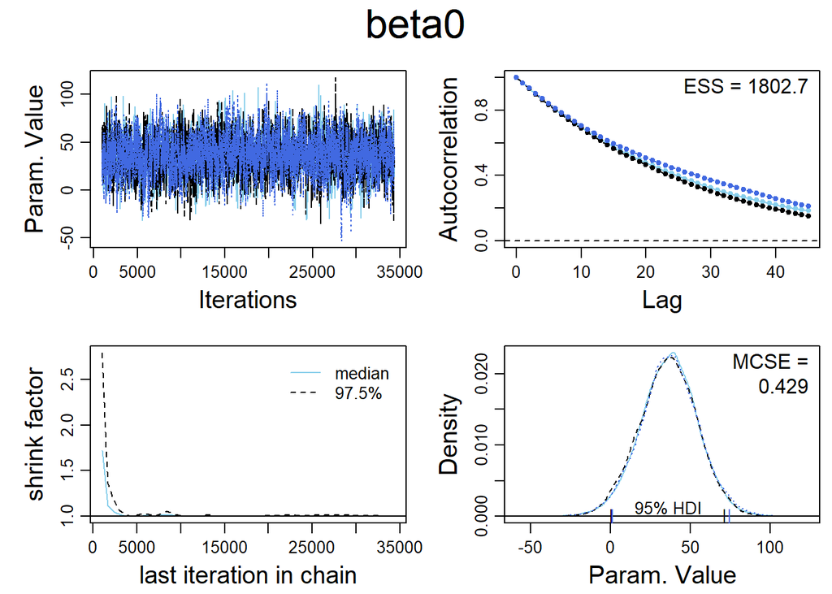

```r
fileNameRoot="JAGS_1/" # For output file names.
dir.create(fileNameRoot)

library(rjags)
Ntotal = length(y)  # Compute the total number of x,y pairs.
dataList = list(    # Put the information into a list.
  x = x,
  y = y ,
  Ntotal = Ntotal
)

# Define the model:
modelString = "
model{
    for( i in 1 : Ntotal ) {
        y[i] ~ dnorm(mu[i], tau)
        mu[i] <- beta0 + beta1 * x[i]
    }
    beta0 ~ dnorm(0.0, 1.0E-6)
    beta1 ~ dnorm(0.0, 1.0E-6)
    sigma ~ dunif(0, 1000)
    tau <- pow(sigma,  -2)
}
" # close quote for modelString
writeLines( modelString , con="TEMPmodel.txt" )
# Initialize the chains based on MLE of data.
initsList = list(beta0 = 0, beta1 = 0, sigma =10)
# Run the chains:
jagsModel = jags.model( file="TEMPmodel.txt" , data=dataList , inits=initsList ,
                        n.chains=3 , n.adapt=500 )
update( jagsModel , n.iter=500 )
codaSamples = coda.samples( jagsModel , variable.names=c("beta0", "beta1", "sigma") ,
                            n.iter=33340 )
save( codaSamples , file=paste0(fileNameRoot,"Mcmc.Rdata") )

varName = 'beta0'
diagMCMC( codaObject=codaSamples , parName=varName )
saveGraph( file=paste0(fileNameRoot,varName) , type="png" )
```

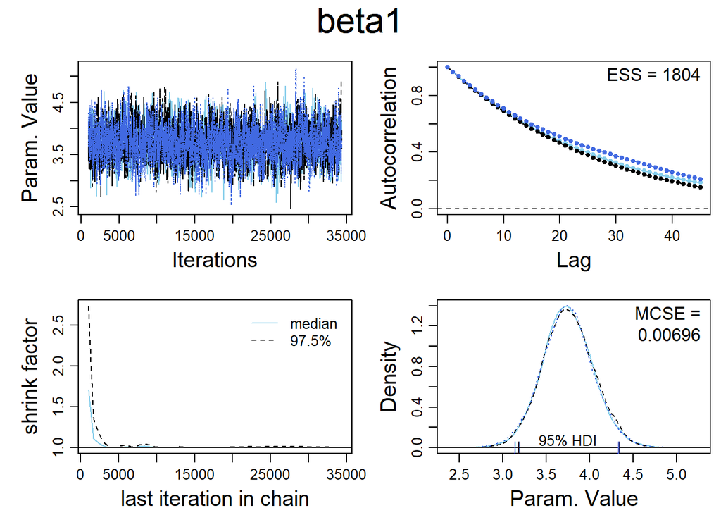

```r
varName = 'beta1'
diagMCMC( codaObject=codaSamples , parName=varName )
saveGraph( file=paste0(fileNameRoot,varName) , type="png" )
```

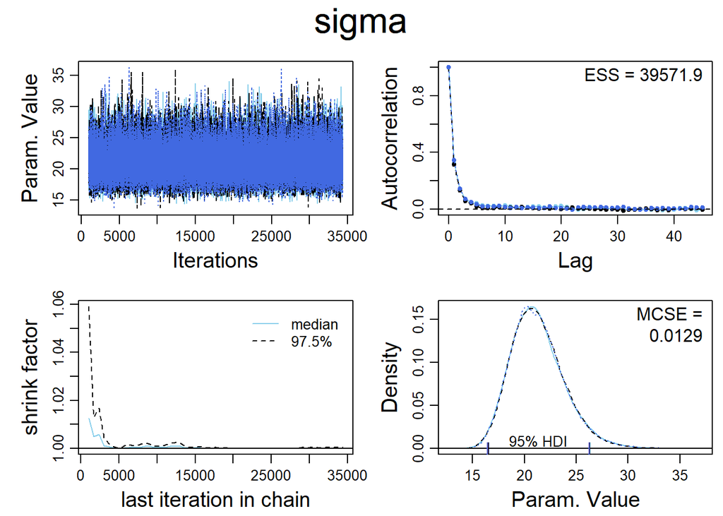

```r
varName = 'sigma'
diagMCMC( codaObject=codaSamples , parName=varName )
saveGraph( file=paste0(fileNameRoot,varName) , type="png" )
```

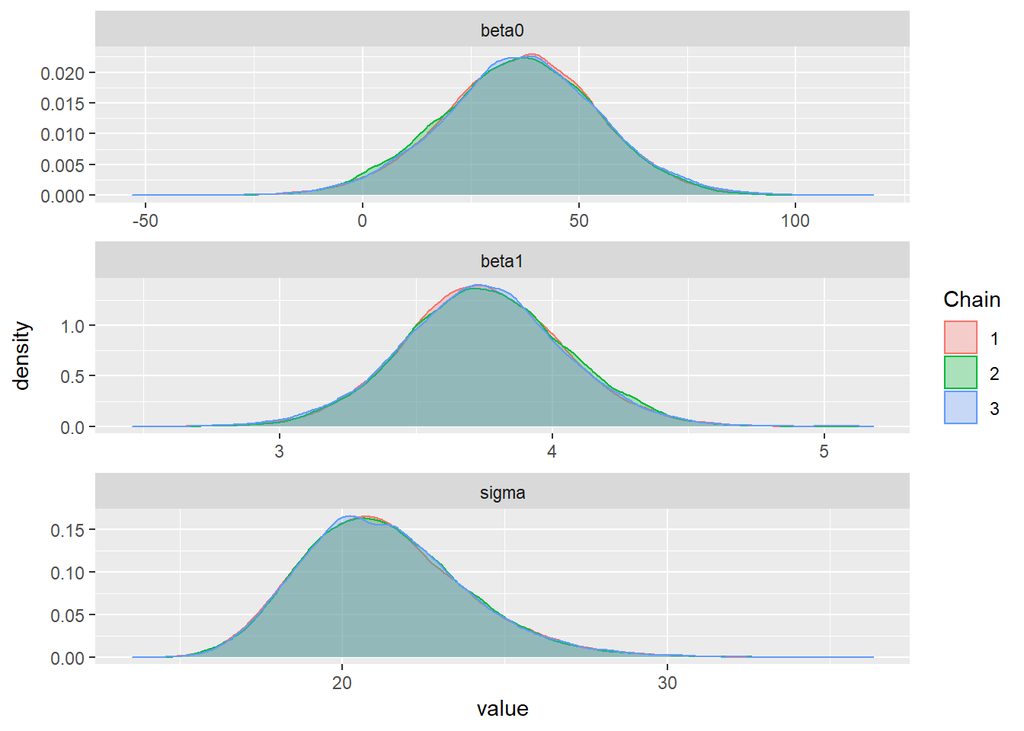

```r
library(ggmcmc)
s = ggs(codaSamples)
d=ggs_density(s)
print(d)
```

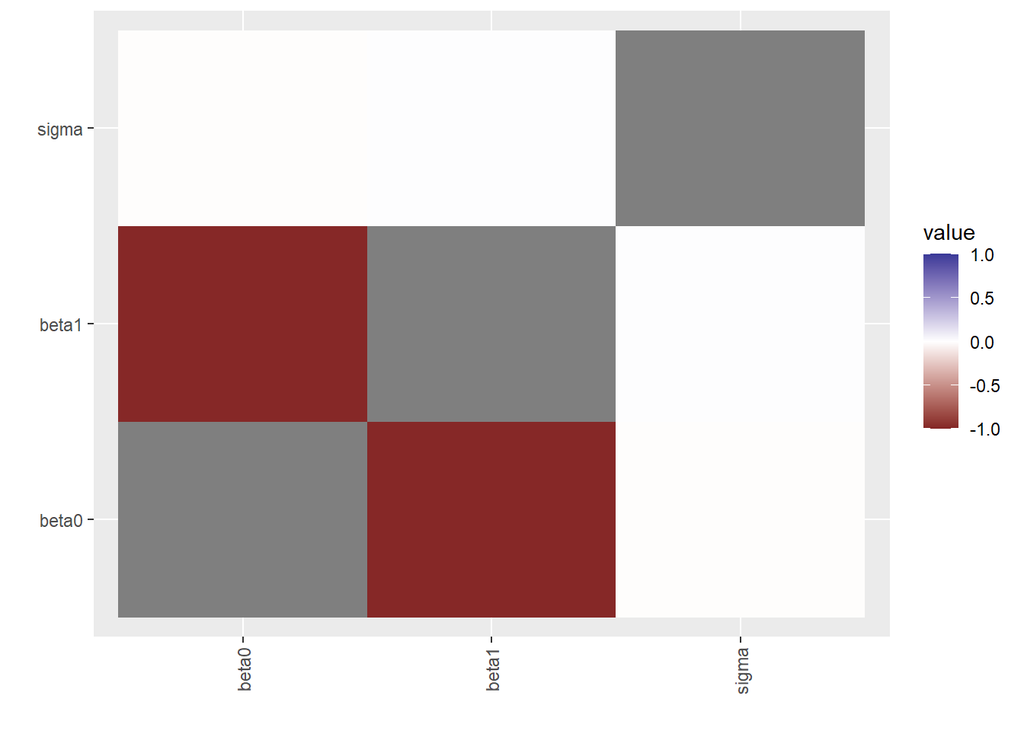

```r
cr =  ggs_crosscorrelation(s)
print(cr)
```

```r
summary(codaSamples)
```

```
##
## Iterations = 1001:34340
## Thinning interval = 1
## Number of chains = 3
## Sample size per chain = 33340
##
## 1. Empirical mean and standard deviation for each variable,
##    plus standard error of the mean:
##
##         Mean      SD  Naive SE Time-series SE
## beta0 36.460 18.2128 0.0575881       0.429298
## beta1  3.747  0.2957 0.0009349       0.006966
## sigma 21.282  2.5587 0.0080906       0.012965
##
## 2. Quantiles for each variable:
##
##           2.5%   25%    50%    75%  97.5%
## beta0  0.04522 24.59 36.693 48.603 71.973
## beta1  3.16934  3.55  3.742  3.939  4.338
## sigma 16.98593 19.48 21.040 22.816 26.978
```

### JAGS Model that Overcomes Outlier

> Overcome outlier by using a distribution with fat tails

```r
fileNameRoot="JAGS_2/" # For output file names.
dir.create(fileNameRoot)
# Specify the data in a list, for later shipment to JAGS:
dataList = list(
  x = x ,
  y = y
)
#-----------------------------------------------------------------------------
# THE MODEL.
modelString = "
# Standardize the data:
data {
  Ntotal <- length(y)
  xm <- mean(x)
  ym <- mean(y)
  xsd <- sd(x)
  ysd <- sd(y)
  for ( i in 1:length(y) ) {
    zx[i] <- ( x[i] - xm ) / xsd
    zy[i] <- ( y[i] - ym ) / ysd
  }
}
# Specify the model for standardized data:
model {
  for ( i in 1:Ntotal ) {
    zy[i] ~ dt( zbeta0 + zbeta1 * zx[i] , 1/zsigma^2 , nu )
  }
  # Priors vague on standardized scale:
  zbeta0 ~ dnorm( 0 , 1/(10)^2 )
  zbeta1 ~ dnorm( 0 , 1/(10)^2 )
  zsigma ~ dunif( 1.0E-3 , 1.0E+3 )
  nu ~ dexp(1/30.0)
  # Transform to original scale:
  beta1 <- zbeta1 * ysd / xsd
  beta0 <- zbeta0 * ysd  + ym - zbeta1 * xm * ysd / xsd
  sigma <- zsigma * ysd
}
" # close quote for modelString
# Write out modelString to a text file
writeLines( modelString , con="TEMPmodel.txt" )
#-----------------------------------------------------------------------------
# INTIALIZE THE CHAINS.
# Let JAGS do it...
#-----------------------------------------------------------------------------
# RUN THE CHAINS
parameters = c( "beta0" ,  "beta1" ,  "sigma",
                "zbeta0" , "zbeta1" , "zsigma", "nu" )

writeLines( modelString , con="TEMPmodel.txt" )

# Run the chains:
jagsModel = jags.model( file="TEMPmodel.txt" , data=dataList ,
                        n.chains=3 , n.adapt=500 )
```

```
## Compiling data graph
##    Initializing
##    Reading data back into data table
##
```

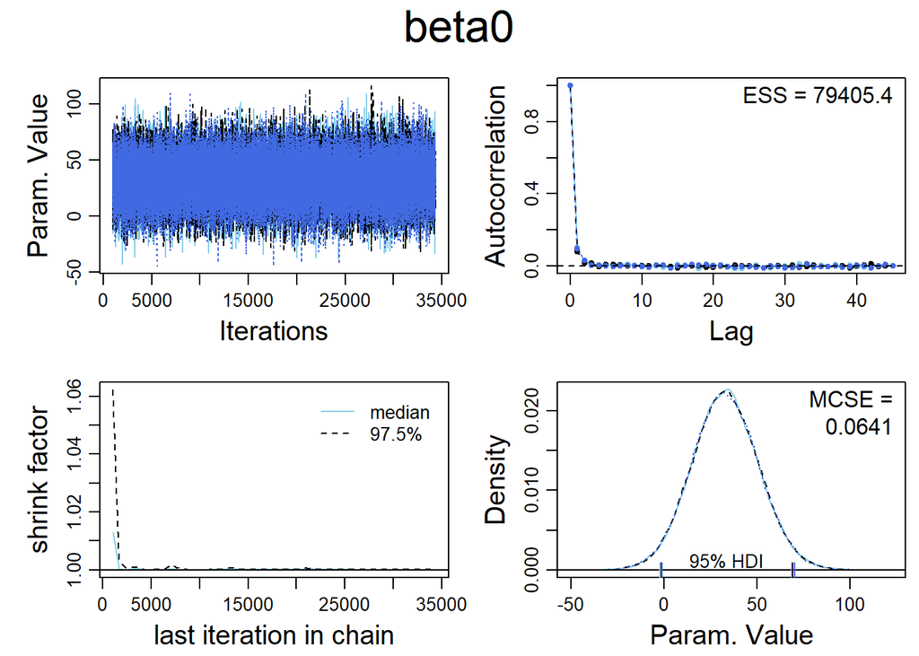

```r
update( jagsModel , n.iter=500 )
codaSamples = coda.samples( jagsModel , variable.names=parameters,
                            n.iter=33340 )
save( codaSamples , file=paste0(fileNameRoot,"Mcmc.Rdata") )

varName = 'beta0'
diagMCMC( codaObject=codaSamples , parName=varName )
saveGraph( file=paste0(fileNameRoot,varName) , type="png" )
```

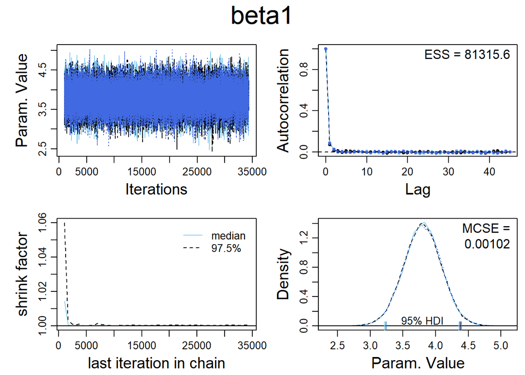

```r
varName = 'beta1'
diagMCMC( codaObject=codaSamples , parName=varName )
saveGraph( file=paste0(fileNameRoot,varName) , type="png" )
```

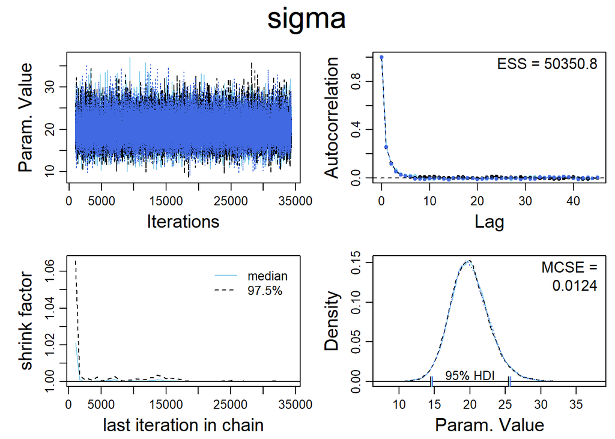

```r
varName = 'sigma'
diagMCMC( codaObject=codaSamples , parName=varName )
saveGraph( file=paste0(fileNameRoot,varName) , type="png" )
```

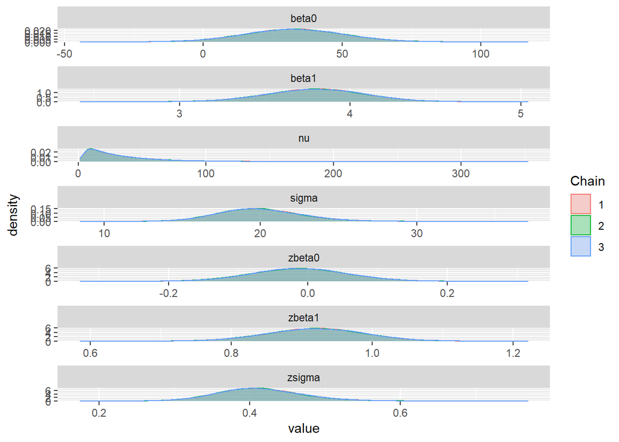

```r
library(ggmcmc)
s = ggs(codaSamples)
d=ggs_density(s)
print(d)
```

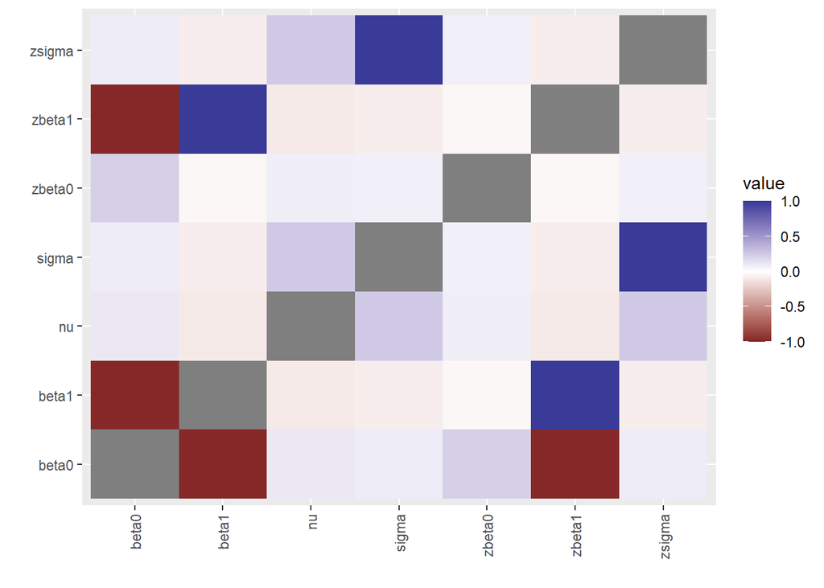

```r
cr =  ggs_crosscorrelation(s)
print(cr)
```

```r
summary(codaSamples)
```

```
##
## Iterations = 1001:34340
## Thinning interval = 1
## Number of chains = 3
## Sample size per chain = 33340
##
## 1. Empirical mean and standard deviation for each variable,
##    plus standard error of the mean:
##
##            Mean       SD  Naive SE Time-series SE
## beta0  32.80097 18.07167 0.0571419      0.0641413
## beta1   3.79796  0.29143 0.0009215      0.0010220
## nu     33.48970 30.49324 0.0964184      0.2482408
## sigma  19.98739  2.79241 0.0088295      0.0124491
## zbeta0 -0.01164  0.06977 0.0002206      0.0002438
## zbeta1  0.92001  0.07060 0.0002232      0.0002476
## zsigma  0.41416  0.05786 0.0001830      0.0002580
##
## 2. Quantiles for each variable:
##
##           2.5%      25%      50%      75%    97.5%
## beta0  -2.4459 20.71591 32.70287 44.83706  68.5680
## beta1   3.2200  3.60463  3.79934  3.99234   4.3675
## nu      3.7769 12.24142 24.10650 44.82680 114.8302
## sigma  14.9037 18.10938 19.83011 21.70298  25.9749
## zbeta0 -0.1484 -0.05824 -0.01194  0.03462   0.1259
## zbeta1  0.7800  0.87317  0.92034  0.96709   1.0580
## zsigma  0.3088  0.37524  0.41090  0.44971   0.5382
```

## Summarize what you have learnt!!

# QR STAN - Introduction

When conducting Bayesian modeling there is a distinction between the theoretical truth of the expressions used and the ability, given the tools available, to sample from the posterior.

In the case of MLR we have

$$E(Y) = \eta = X\beta$$

If the sampler is moving through the space of the $\beta$ parameters ($\beta_0,\beta_1\ldots , \beta_k$) and these are highly correlated then the sampler will jump in small steps and not quickly visit a representative subset of the parameter space.

To get over this we can factor the design matrix $X$ by using the thin QR factorization theorem (as opposed to the “fat” one).

$$X_{n\times (k+1)}=Q_{n\times (k+1)}R_{(k+1)\times (k+1)}$$
Where Q contains orthogonal columns and R is an upper triangular matrix.

To help in the calculation we can define

$$X = Q^*R^*$$

where $Q^*=Q \sqrt{n-1}$ and $R^* = R \frac{1}{\sqrt{n-1}}$.

This means that

$$\eta = X\beta = Q^*R^* \beta = Q^*\theta$$

where $\theta = R^* \beta$. To estimate $\theta$, however, we do not need to know $\beta$, that is, we will not find $\theta$ from $\beta$ but the reverse. Our regression will be using $\theta$ as the unknown parameters. This will give better sampling characteristics and then we will apply the transformation

$$\beta = (R^*)^{-1}\theta$$

to find the wanted posterior $\beta$ parameters.

## R example

To show you how to the QR factorization works we will use the ddt data set.

First lets make X

```r
ddt <- Intro2R::ddt
X <- model.matrix(LENGTH ~ WEIGHT + DDT, ddt)
head(X,2)
```

```
##   (Intercept) WEIGHT DDT
## 1           1    732  10
## 2           1    795  16
```

Now we will use the `qr()` function

```r
QR <- qr(X)
Q <- qr.Q(QR)
R <- qr.R(QR)
head(Q)
```

```
##             [,1]        [,2]         [,3]
## [1,] -0.08333333 -0.07055892 -0.013043077
## [2,] -0.08333333 -0.05656774 -0.007775982
## [3,] -0.08333333 -0.11164413 -0.002481158
## [4,] -0.08333333 -0.12985487 -0.004398154
## [5,] -0.08333333  0.04492384  0.022335308
## [6,] -0.08333333  0.04559009  0.107351709
```

```r
R
```

```
##   (Intercept)     WEIGHT        DDT
## 1         -12 -12596.583 -292.26000
## 2           0   4502.837  -14.00628
## 3           0      0.000 1176.35340
```

Notice that Q has the same dimension as X and has orthogonal columns.

```r
dim(X)
```

```
## [1] 144   3
```

```r
dim(Q)
```

```
## [1] 144   3
```

```r
round(t(Q)%*%Q,4)
```

```
##      [,1] [,2] [,3]
## [1,]    1    0    0
## [2,]    0    1    0
## [3,]    0    0    1
```

Once we have Q and R we can make $Q^*$ and $R^*$.

We can verify that the factorization is correct

```r
head(round(Q%*%R-X,5))
```

```
##      (Intercept) WEIGHT DDT
## [1,]           0      0   0
## [2,]           0      0   0
## [3,]           0      0   0
## [4,]           0      0   0
## [5,]           0      0   0
## [6,]           0      0   0
```

## More documentation

Please note that you **MUST** read the following items:

- https://mc-stan.org/docs/2_28/stan-users-guide/QR-reparameterization.html
- https://en.wikipedia.org/wiki/QR_decomposition

## A STAN model

Because we wish to carry out a regression in STAN we must use STAN functions.

The basic STAN blocks are **data**, **parameters**, and **model**. We will need extra blocks to carry out our thin QR on the data (**transformed data**) and another block for the transformation of $\theta$ to $\beta$ (**generated quantities**).

## STAN code with extra blocks

Please look at the code below and see how the QR factorization plays out in practice. These tools will really help with making the ampler work more efficiently.

```r
library(rstan)
library(Intro2R)
library(shinystan)



with(ddt, lm(LENGTH ~ SPECIES))->ylm
X <- model.matrix(ylm)# make a design matrix
y <- ddt[,"LENGTH"]


dataslr5 <- list(X = X, y = y, N = length(y),nbetas=dim(X)[2])
```

### `SLR2-Q.stan`

```stan
data {
  int<lower=0> N;
  int<lower=0> nbetas;
  matrix[N,nbetas] X; // Design matrix
  vector[N] y; // Vector of response values
}

transformed data {
matrix[N, nbetas] Q_ast;
matrix[nbetas, nbetas] R_ast;
matrix[nbetas, nbetas] R_ast_inverse;
// thin and scale the QR decomposition
Q_ast = qr_thin_Q(X) * sqrt(N - 1);
R_ast = qr_thin_R(X) / sqrt(N - 1);
R_ast_inverse = inverse(R_ast);
}


parameters {
  vector[nbetas] theta; // vector of real theta
  real<lower=0> sigma; // STD
}
model {
  y ~ normal( Q_ast * theta, sigma ); // mvn mean Xbeta
  theta ~ normal(0,100);// mvn
  sigma ~ gamma(1,1); // univariate
}

generated quantities {
  vector[nbetas] beta;
  beta = R_ast_inverse * theta; // coefficients on x
}
```

```r
options(mc.cores = parallel::detectCores())

fit5 <- stan(file = "SLR2-Q.stan",
             model_name = "Simple Linear Regression matrix Q",
             data = dataslr5,
             chains = 3,
             warmup = 1000,
             iter = 3000,
             pars = c("beta", "sigma")
)

library(shinystan)

afit5 <- as.shinystan(fit5)
shinystan::launch_shinystan(afit5)
```

# Questions

- Make the above code run and make a screen shot of the posterior histograms of the Diagnostic page, NUTS(Plots) Tab, Parameter: beta[3] all else default. Include the picture in your write up.

[figure not shown]

[figure not shown]

- Make a screen shot of the Explore page, beta[1], Multiview. Add the picture to your write up
- Now change the STAN code so that you do not transform the data using the QR transformation. That is the model will use $\beta$ directly. Make copies of the above two pages for the new model.

### `SLR2-Q-1.stan`

```stan
data {
  int<lower=0> N;   // number of data items
  int<lower=0> K;   // number of predictors
  matrix[N, K] x;   // predictor matrix
  vector[N] y;      // outcome vector
}
transformed data {
  matrix[N, K] Q_ast;
  matrix[K, K] R_ast;
  matrix[K, K] R_ast_inverse;
  // thin and scale the QR decomposition
  Q_ast = qr_thin_Q(x) * sqrt(N - 1);
  R_ast = qr_thin_R(x) / sqrt(N - 1);
  R_ast_inverse = inverse(R_ast);
}
parameters {
  real alpha;           // intercept
  vector[K] theta;      // coefficients on Q_ast
  real<lower=0> sigma;  // error scale
}
model {
  y ~ normal(Q_ast * theta + alpha, sigma);  // likelihood
}
generated quantities {
  vector[K] beta;
  beta = R_ast_inverse * theta; // coefficients on x
}
```

```r
options(mc.cores = parallel::detectCores())

fit5 <- stan(file = "SLR2-Q-1.stan",
             model_name = "Simple Linear Regression matrix Q 2",
             data = dataslr5,
             chains = 3,
             warmup = 1000,
             iter = 3000,
             pars = c("beta", "sigma")
)

afit6 <- as.shinystan(fit5)
shinystan::launch_shinystan(afit6)
```

Attempted to create model but was unsuccessful since there was little documentation on this.